# Full SEM

# From CFA to Full SEM

## What is Full SEM?

SEM = CFA (measurement) + Path analysis (structural)

- **Measurement model**: how latent variables are measured by indicators
- **Structural model**: directional relations among latent variables

Unlike observed-score path models, SEM explicitly accounts for measurement error.

## An Example of Full SEM

[figure not shown]

## Why Use Full SEM?

- We can test mediation or direct effects among **latent** constructs
- Path coefficients are less attenuated by measurement error
- Model fit evaluates whether the full covariance structure is plausible

**Note**

SEM is especially useful when your substantive hypotheses are causal but your key variables are latent.

# Example: SOP, NGSE, and PASS

## Example Data

- **Data source**: Williams & Edwards ([2021](https://cipp.ug.edu.pl/Conceptual-replication-of-Seo-2008-Self-efficacy-as-a-mediator-in-the-relationship,142208,0,2.html), conceptual replication of Seo, 2008)
- **Sample size**: $N = 575$
- Constructs:
  - `SOP`: Self-Oriented Perfectionism (5 items)
  - `NGSE`: General Self-Efficacy (8 items)
  - `PASS`: Academic Procrastination (4 parcels: assignments, exams, reading, general)

## Hypothesized Mediation Model

[figure not shown]

Figure 1

$$\begin{aligned}
\text{NGSE} &= a\cdot\text{SOP} + \zeta_1 \\
\text{PASS} &= b\cdot\text{NGSE} + c'\cdot\text{SOP} + \zeta_2
\end{aligned}$$

## Two-Step SEM Workflow

1. **Step 1: Full Measurement model (CFA)**
   - Verify indicators measure intended factors
   - Check global fit and loading pattern
2. **Step 2: Structural model (SR/SEM)**
   - Impose directional paths among latent factors
   - Evaluate direct, indirect, and total effects

**Note**

If Step 1 is poor, Step 2 interpretations are not trustworthy.

# Step 1: Measurement Model

## Data Overview

Mean

SD

Min

Median

Max

Histogram

SOP_1

3.5

1.1

1.0

4.0

5.0

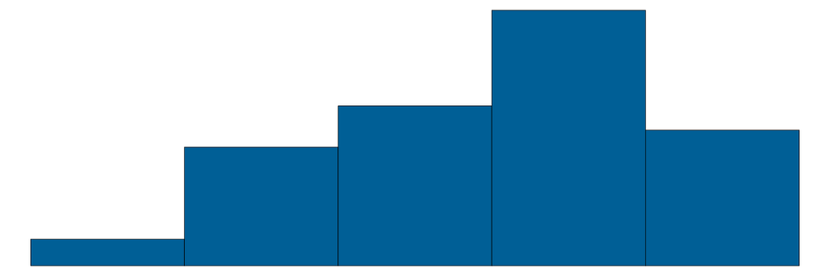

SOP_2

3.3

1.2

1.0

3.0

5.0

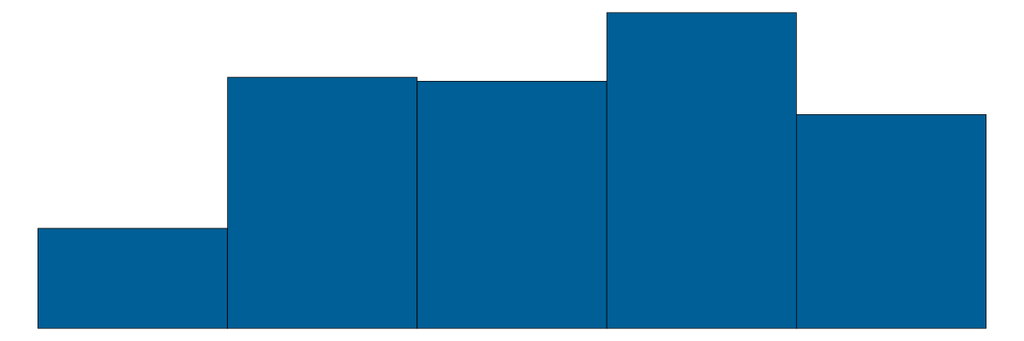

SOP_3

3.0

1.1

1.0

3.0

5.0

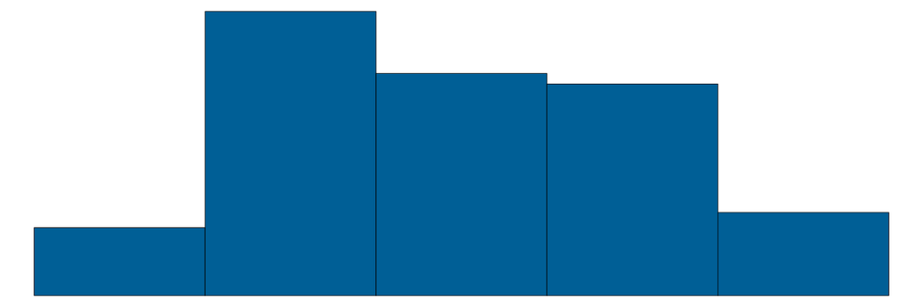

SOP_4

3.0

1.2

1.0

3.0

5.0

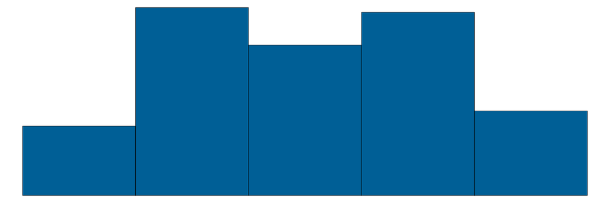

SOP_5

2.6

1.2

1.0

2.0

5.0

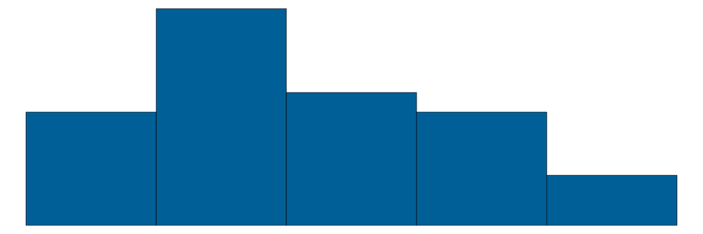

NGSE_1

3.9

0.8

1.0

4.0

5.0

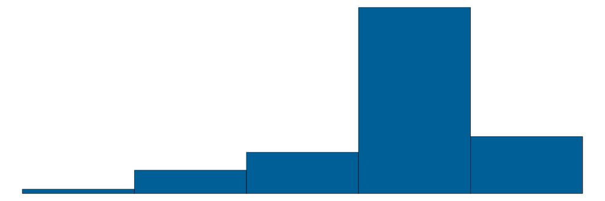

NGSE_2

3.7

1.0

1.0

4.0

5.0

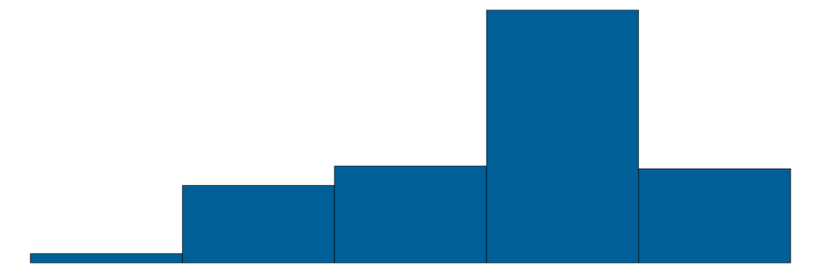

NGSE_3

4.1

0.8

1.0

4.0

5.0

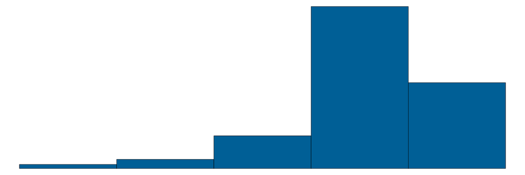

NGSE_4

3.9

1.0

1.0

4.0

5.0

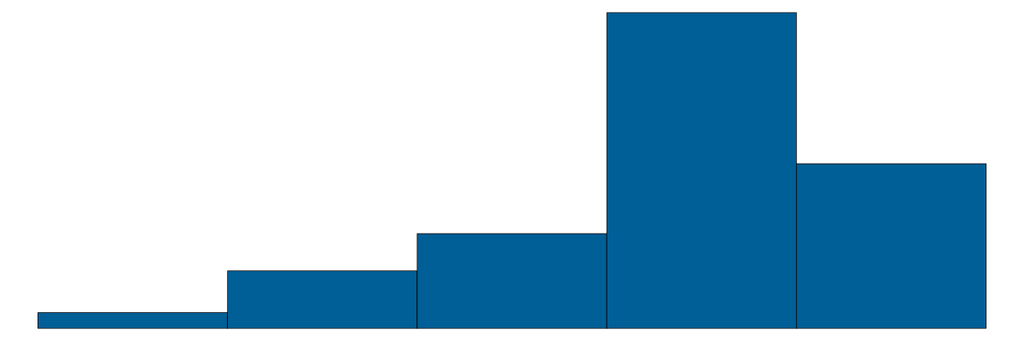

NGSE_5

3.9

0.9

1.0

4.0

5.0

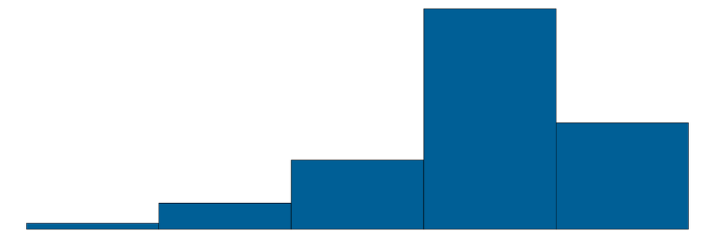

NGSE_6

3.9

1.0

1.0

4.0

5.0

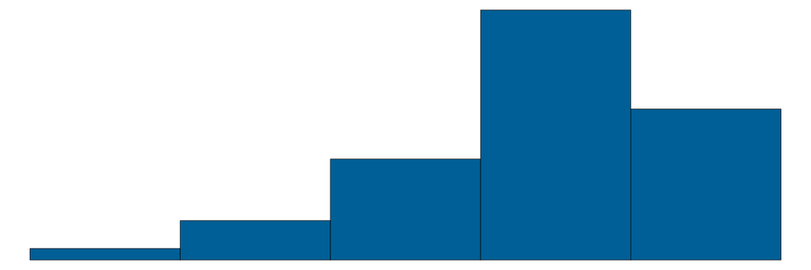

NGSE_7

3.7

1.0

1.0

4.0

5.0

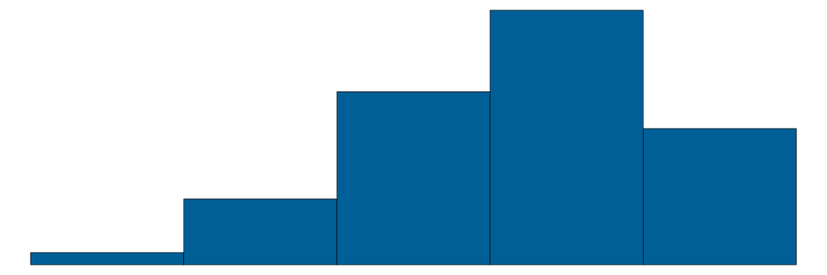

NGSE_8

3.7

1.0

1.0

4.0

5.0

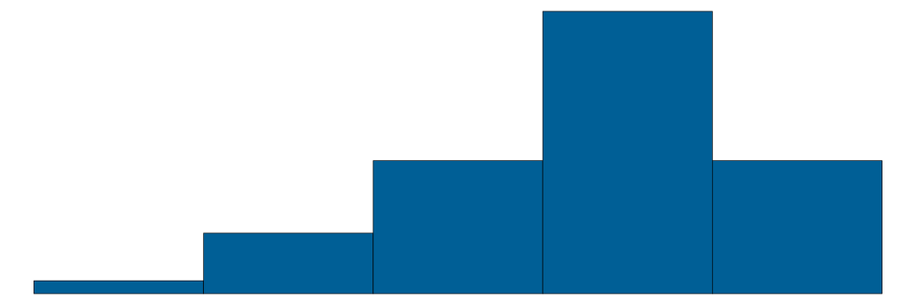

Pasgn

10.9

2.5

3.0

11.0

15.0

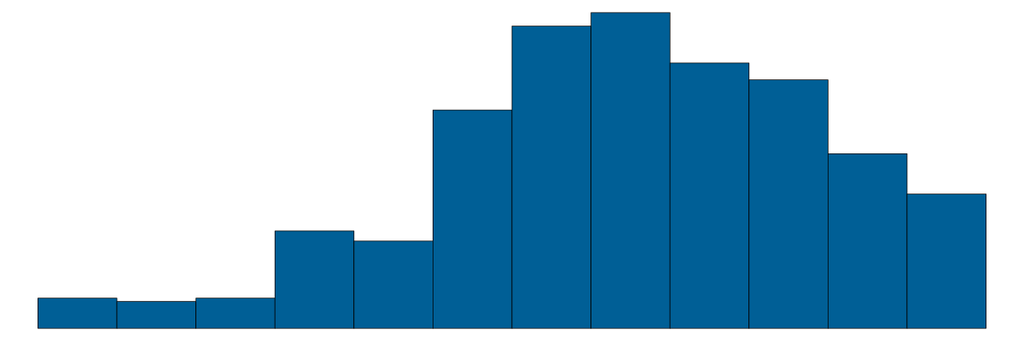

Pexam

10.8

2.8

3.0

11.0

15.0

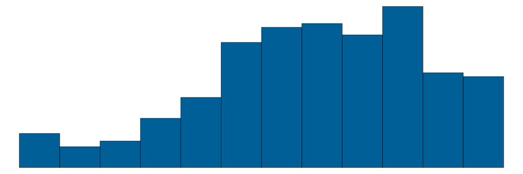

Pread

10.0

3.3

3.0

10.0

15.0

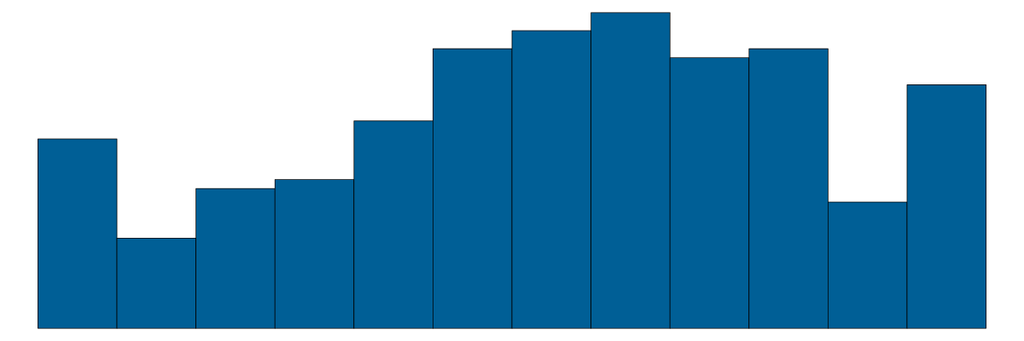

Pgen

10.3

2.6

3.0

10.0

15.0

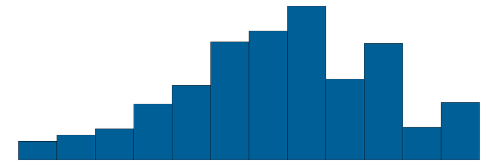

## Correlation Structure

|  | 1 | 2 | 3 | 4 | 5 | 6 | 7 | 8 | 9 | 10 | 11 | 12 | 13 | 14 | 15 | 16 | 17 |
| --- | --- | --- | --- | --- | --- | --- | --- | --- | --- | --- | --- | --- | --- | --- | --- | --- | --- |
| 1. SOP_1 | 1 | . | . | . | . | . | . | . | . | . | . | . | . | . | . | . | . |
| 2. SOP_2 | .77 | 1 | . | . | . | . | . | . | . | . | . | . | . | . | . | . | . |
| 3. SOP_3 | .67 | .68 | 1 | . | . | . | . | . | . | . | . | . | . | . | . | . | . |
| 4. SOP_4 | .68 | .75 | .74 | 1 | . | . | . | . | . | . | . | . | . | . | . | . | . |
| 5. SOP_5 | .46 | .55 | .57 | .61 | 1 | . | . | . | . | . | . | . | . | . | . | . | . |
| 6. NGSE_1 | .24 | .14 | .18 | .15 | .05 | 1 | . | . | . | . | . | . | . | . | . | . | . |
| 7. NGSE_2 | .18 | .10 | .20 | .13 | .07 | .53 | 1 | . | . | . | . | . | . | . | . | . | . |
| 8. NGSE_3 | .11 | .02 | .10 | .03 | -.03 | .53 | .58 | 1 | . | . | . | . | . | . | . | . | . |
| 9. NGSE_4 | .17 | .11 | .21 | .13 | .09 | .45 | .53 | .54 | 1 | . | . | . | . | . | . | . | . |
| 10. NGSE_5 | .19 | .11 | .21 | .13 | .07 | .48 | .56 | .56 | .60 | 1 | . | . | . | . | . | . | . |
| 11. NGSE_6 | .12 | .06 | .13 | .07 | .06 | .35 | .48 | .47 | .47 | .59 | 1 | . | . | . | . | . | . |
| 12. NGSE_7 | .28 | .19 | .27 | .21 | .09 | .36 | .45 | .41 | .44 | .46 | .55 | 1 | . | . | . | . | . |
| 13. NGSE_8 | .13 | .07 | .16 | .08 | .04 | .40 | .51 | .48 | .47 | .55 | .53 | .60 | 1 | . | . | . | . |
| 14. Pasgn | -.09 | -.01 | -.10 | -.05 | .08 | -.24 | -.22 | -.16 | -.17 | -.15 | -.13 | -.16 | -.17 | 1 | . | . | . |
| 15. Pexam | -.08 | .02 | -.07 | -.05 | .06 | -.17 | -.15 | -.07 | -.05 | -.07 | -.05 | -.08 | -.13 | .58 | 1 | . | . |
| 16. Pread | -.05 | .04 | -.04 | -.01 | .03 | -.19 | -.11 | -.12 | -.06 | -.11 | -.07 | -.04 | -.08 | .50 | .44 | 1 | . |
| 17. Pgen | -.06 | -.01 | -.06 | -.02 | .08 | -.22 | -.17 | -.16 | -.12 | -.10 | -.02 | -.06 | -.10 | .64 | .54 | .51 | 1 |

## CFA Model Specification

```r
model_cfa_we <- "
  SOP  =~ SOP_1 + SOP_2 + SOP_3 + SOP_4 + SOP_5
  NGSE =~ NGSE_1 + NGSE_2 + NGSE_3 + NGSE_4 +
          NGSE_5 + NGSE_6 + NGSE_7 + NGSE_8
  PASS =~ Pasgn + Pexam + Pread + Pgen
"
fit_cfa_we <- cfa(
    model_cfa_we,
    data = we_data,
    std.lv = TRUE,
    estimator = "MLR",
    missing = "FIML"
)
summary(fit_cfa_we, fit.measures = TRUE, standardized = TRUE)
```

### CFA Fit

| Model | Chisq | df | CFI* | RMSEA* | SRMR |
| --- | --- | --- | --- | --- | --- |
| CFA | 344.363 | 116 | 0.945 | 0.063 | 0.05 |

### Standardized Loadings

| ind | loading |
| --- | --- |
| SOP_1 | 0.817 |
| SOP_2 | 0.872 |
| SOP_3 | 0.822 |
| SOP_4 | 0.870 |
| SOP_5 | 0.651 |

| ind | loading |
| --- | --- |
| NGSE_1 | 0.628 |
| NGSE_2 | 0.740 |
| NGSE_3 | 0.723 |
| NGSE_4 | 0.717 |
| NGSE_5 | 0.782 |
| NGSE_6 | 0.693 |
| NGSE_7 | 0.654 |
| NGSE_8 | 0.708 |

| ind | loading |
| --- | --- |
| Pasgn | 0.816 |
| Pexam | 0.697 |
| Pread | 0.628 |
| Pgen | 0.788 |

# Step 2: Structural Model

## SR Model Specification

```r
model_sr_we <- "
  # Measurement model
  SOP  =~ SOP_1 + SOP_2 + SOP_3 + SOP_4 + SOP_5
  NGSE =~ NGSE_1 + NGSE_2 + NGSE_3 + NGSE_4 +
          NGSE_5 + NGSE_6 + NGSE_7 + NGSE_8
  PASS =~ Pasgn + Pexam + Pread + Pgen

  # Structural model (mediation)
  NGSE ~ a * SOP
  PASS ~ b * NGSE + c * SOP

  # Defined parameters
  indirect := a * b
  total    := c + a * b
"
fit_sr_we <- sem(
    model_sr_we,
    data = we_data,
    std.lv = TRUE,
    estimator = "MLR",
    missing = "FIML"
)
summary(fit_sr_we, fit.measures = TRUE, standardized = TRUE, rsquare = TRUE)
```

## Structural Model Diagram

[figure not shown]

Figure 2

## Structural Paths and Indirect Effect

| lhs | op | rhs | est | se | z | pvalue | std.all |
| --- | --- | --- | --- | --- | --- | --- | --- |
| NGSE | ~ | SOP | 0.220 | 0.057 | 3.886 | 0.000 | 0.215 |
| PASS | ~ | NGSE | -0.243 | 0.052 | -4.646 | 0.000 | -0.242 |
| PASS | ~ | SOP | 0.003 | 0.049 | 0.069 | 0.945 | 0.003 |
| indirect | := | a*b | -0.054 | 0.018 | -3.040 | 0.002 | -0.052 |
| total | := | c+a*b | -0.050 | 0.048 | -1.051 | 0.293 | -0.049 |

## Fit Comparison: Step 1 vs Step 2

| Model | Chisq* | df | CFI* | RMSEA* | SRMR |
| --- | --- | --- | --- | --- | --- |
| Step 1: CFA | 344.363 | 116 | 0.945 | 0.063 | 0.05 |
| Step 2: SEM | 344.363 | 116 | 0.945 | 0.063 | 0.05 |

## Interpretation of Effects

- **Indirect effect**: $a \times b$ (SOP $\rightarrow$ NGSE $\rightarrow$ PASS)
- **Direct effect**: $c'$ (SOP $\rightarrow$ PASS, controlling for NGSE)
- **Total effect**: $c' + a\times b$

**Note**

If the 95% CI for the indirect effect excludes 0, the mediation effect is statistically supported.

## Brief Causal Caution

- A fitted SEM does **not** prove causal direction
- Causal interpretation depends on assumptions (no key omitted confounders)
- Equivalent/reversed models may show similar global fit

**Warning**

Use theory and design (not fit indices alone) to justify directional claims.

## Summary

- Structural regression combines CFA and path analysis in one model
- Use the two-step strategy: validate measurement first, then test structure
- Indirect effects are straightforward in *lavaan* using `:=`
- Good fit supports plausibility, but does not establish causality by itself

## Exercise

1. Fit the measurement model using `we_data` and check fit.
   1. Which factor has the strongest average standardized loading?
2. Fit the structural mediation model without the direct path (c’):

   ```r
   model2_sr_we <- "
     SOP  =~ SOP_1 + SOP_2 + SOP_3 + SOP_4 + SOP_5
     NGSE =~ NGSE_1 + NGSE_2 + NGSE_3 + NGSE_4 +
             NGSE_5 + NGSE_6 + NGSE_7 + NGSE_8
     PASS =~ Pasgn + Pexam + Pread + Pgen

     NGSE ~ a * SOP
     PASS ~ b * NGSE

     indirect := a * b
   "
   fit2_sr_we <- sem(model2_sr_we, data = we_data,
                     std.lv = TRUE, estimator = "MLR", missing = "FIML")
   ```

   1. Compare fit to the model with the direct path:

   ```r
   anova(fit_sr_we, fit2_sr_we)
   ```

[interactive chart not shown]